# Algorithmes de tri

## Préambule

Quelques liens pour découvrir et comparer des algorithmes de tris :

- Article de Wikipedia
- [Article du site Interstices](http://interstices.info/jcms/c_6973/les-algorithmes-de-tri)
- [Comparaison des algorithmes de tris](http://www.sorting-algorithms.com/)

Au fait ce texte saisi dans une cellule du [notebook d'IPython](http://ipython.org/) utilise le langage de balises [Markdown](http://daringfireball.net/projects/markdown/), surcouche d'HTML.

## Imports des modules

```python
import numpy as np
import matplotlib.pyplot as plt
import time
from random import randint
```

```python
%matplotlib inline
```

## Tests de correction

```python
#Pour tester les fonctions de tri
#un tableau contenant 3 tableaux d'entiers aléatoires de tailles 10, 100, 1000
BENCH2 = [[randint(1, 2*10**i) for _ in range(10**i)] for i in range(1,4)]

#idem mais avec 3 tableaux d'entiers aléatoires de tailles impaires
BENCH1 = [[randint(1, 2*10**i) for _ in range(10**i + 1)] for i in range(1,4)]

def bontri(t):
    '''Détermine si un tableau est trié dans l'ordre croissant'''
    for k in range(len(t)-1):
        if t[k] > t[k+1]:
            return False
    return True

def procedure_to_fonction(f):
    '''Remplace la fonction f qui est une procedure ne retournant rien par une
    fonction fbis qui exécute f sur ses arguments puis retourne ses arguments.
    Nécessaire pour composer une fonction de tri sur place avec bontri'''

    def fbis(*args):
        f(*args)
        return args

    return fbis

def test_tri(tri, BENCH):
    #copie profonde de BENCH qui est un tableau de tableaux
    COPIE = [t[:] for t in BENCH]
    return [bontri(procedure_to_fonction(tri)(t)) for t in COPIE]
```

### Chronomètre

```python
def timetest(fonction):
    """exécute la fonction et affiche son temps d'exécution """

    def fonction_modifiee(*args,**kargs):
        debut = time.perf_counter()
        fonction(*args,**kargs)
        return time.perf_counter() - debut

    return fonction_modifiee
```

## Tri par sélection

### Implémentations du tri par sélection

```python
def index_mini(t, debut):
    if t == []:
        return None
    imini = debut
    for j in range(debut + 1, len(t)):
        if t[j] < t[imini]:
            imini = j
    return imini

def tri_selection(t):
    '''Tri par sélection avec sélection du minimum'''
    n = len(t)
    for debut in range(n - 1):
        imini = index_mini(t, debut)
        t[debut], t[imini] = t[imini], t[debut]

def index_maxi(t, fin):
    if t == []:
        return None
    imaxi = fin
    for j in range(0, fin):
        if t[j] > t[imaxi]:
            imaxi = j
    return imaxi

def tri_selection2(t):
    '''Tri par sélection avec sélection du maximum'''
    n = len(t)
    for fin in range(n - 1, 0, -1):
        imaxi = index_maxi(t, fin)
        t[fin], t[imaxi] = t[imaxi], t[fin]
```

### Test de correction du tri par sélection

```python
for tri in [tri_selection, tri_selection2]:
    print(test_tri(tri, BENCH1))
    print(test_tri(tri, BENCH2))
```

```
[True, True, True]
[True, True, True]
[True, True, True]
[True, True, True]
```

### Complexité du tri par sélection

- [Article de Wikipedia](http://fr.wikipedia.org/wiki/Tri_par_sélection)
- [Le site sorting algorithms](http://www.sorting-algorithms.com/selection-sort)

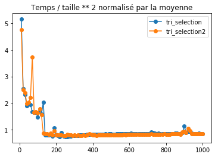

```python
liste_tris = [tri_selection, tri_selection2]
liste_taille = list(range(10, 1001, 10))
liste_rapport_carre = np.array([[0 for _ in range(len(liste_taille))] for _ in range(len(liste_tris))], dtype='float')
for i, taille in enumerate(liste_taille):
    liste = [randint(0, taille) for _ in range(taille)]
    for j, tri in enumerate(liste_tris):
        liste_rapport_carre[j][i] = timetest(tri)(liste[:]) / (liste_taille[i]) ** 2
for k, rapport_carre in enumerate(liste_rapport_carre):
    plt.plot(liste_taille, rapport_carre / rapport_carre.mean(), label=liste_tris[k].__name__, marker='o')
plt.title(r"Temps / taille ** 2 normalisé par la moyenne")
plt.legend()
plt.savefig('complexite-quadratique-tri_selection.png')
```

## Tri par bulles

L'algorithme du tri par bulles consiste à trier un tableau en ne s'autorisant qu'à échanger deux éléments consécutifs de ce tableau. On peut démontrer que l'algorithme suivant trie n'importe quel tableau :

- chercher deux éléments consécutifs rangés dans le désordre ;
- si deux tels éléments existent, les échanger et recommencer ;
- sinon arrêter.

Descriptions du tri par bulles :

- [Article de Wikipedia](http://fr.wikipedia.org/wiki/Tri_%C3%A0_bulles)
- [Le site sorting algorithms](http://www.sorting-algorithms.com/bubble-sort)

### Implémentations du tri par bulles

```python
def tri_bulles(t):
    n = len(t)
    for bulle in range(n - 1):
        for k in range(0, n - 1 - bulle):
            if t[k + 1] < t[k]:
                t[k + 1], t[k] = t[k], t[k + 1]


def tri_bulles2(t):
    n = len(t)
    continuer = True
    bulle = 0
    while continuer:
        continuer = False
        for k in range(0, n - 1 - bulle):
            if t[k + 1] < t[k]:
                t[k + 1], t[k] = t[k], t[k + 1]
                continuer = True
        bulle += 1
```

### Test de correction du tri par bulles

```python
for tri in [tri_bulles, tri_bulles2]:
    print(test_tri(tri, BENCH1))
    print(test_tri(tri, BENCH2))
```

```
[True, True, True]
[True, True, True]
[True, True, True]
[True, True, True]
```

### Complexité du tri par bulles

1. Tri par bulles de la liste [72, 39, 29, 59] :
   - Etape 1 [39,72,29,59]
   - Etape 2 [39,29,72,59]
   - Etape 3 [39,29,59,72]
   - Etape 4 [29,39,59,72]
2. Implémentation en Python du Tri par bulles, coir ci-dessous plusieurs versions.
3. Selon l'implémentation `tri_bulles` ou `tri_bulles2` (voir ci-dessus) la complexité du tri par bulles est **quadratique** (comme pour le tri par sélection) ou **linéaire** (comme pour le tri par insertion) sur *les listes déjà triées*.
4. Si on applique le tri par bulles à une liste triée dans l'ordre décroissant comme $[n,n-1,n-2,..,1]$, quelle que soit l'implémentation, on a besoin de $i-1$ permutations (comparaison + échange) pour $i$ allant de $n$ à $1$ soit un total de $(n-1)+(n-2)+\cdots+1=\frac{n(n-1)}{2}$ permutations. La complexité du tri par bulles est donc **quadratique** sur les listes triées dans l'ordre inverse.

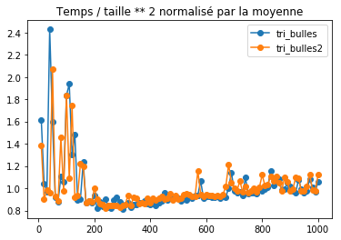

```python
liste_tris = [tri_bulles, tri_bulles2]
liste_taille = list(range(10, 1001, 10))
liste_rapport_carre = np.array([[0 for _ in range(len(liste_taille))] for _ in range(len(liste_tris))], dtype='float')
for i, taille in enumerate(liste_taille):
    liste = [randint(0, taille) for _ in range(taille)]
    for j, tri in enumerate(liste_tris):
        liste_rapport_carre[j][i] = timetest(tri)(liste[:]) / (liste_taille[i]) ** 2
for k, rapport_carre in enumerate(liste_rapport_carre):
    plt.plot(liste_taille, rapport_carre / rapport_carre.mean(), label=liste_tris[k].__name__, marker='o')
plt.title(r"Temps / taille ** 2 normalisé par la moyenne")
plt.legend()
plt.savefig('complexite-quadratique-tri_bulles.png')
```

## Tri par insertion

### Implémentations du tri par insertion

```python
def insertion(t, k):
    """A partir de l'indice k, insère l'élément t[k] de t
    à sa place dans t[:k] triée dans l'ordre croissant"""
    i = k - 1
    element = t[k]
    while i >= 0 and t[i] > element:
        t[i + 1] = t[i]
        i = i - 1
    t[i] = element

def tri_insertion(t):
    n = len(t)
    for k in range(1, n):
        insertion(t, k)
```

### Test de correction du tri par insertion

```python
for tri in [tri_insertion]:
    print(test_tri(tri, BENCH1))
    print(test_tri(tri, BENCH2))
```

[output not shown]

### Complexité du tri par insertion

Analyse de complexité du tri par insertion :

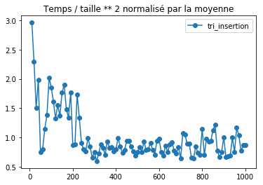

```python
liste_tris = [tri_insertion]
liste_taille = list(range(10, 1001, 10))
liste_rapport_carre = np.array([[0 for _ in range(len(liste_taille))] for _ in range(len(liste_tris))], dtype='float')
for i, taille in enumerate(liste_taille):
    liste = [randint(0, taille) for _ in range(taille)]
    for j, tri in enumerate(liste_tris):
        liste_rapport_carre[j][i] = timetest(tri)(liste[:]) / (liste_taille[i]) ** 2
for k, rapport_carre in enumerate(liste_rapport_carre):
    plt.plot(liste_taille, rapport_carre / rapport_carre.mean(), label=liste_tris[k].__name__, marker='o')
plt.title(r"Temps / taille ** 2 normalisé par la moyenne")
plt.legend()
plt.savefig('complexite-quadratique-tri_insertion.png')
```

## Tri fusion

Descriptions du tri par fusion :

- [Article de Wikipedia](http://fr.wikipedia.org/wiki/Tri_fusion)
- [Le site sorting algorithms](http://www.sorting-algorithms.com/merge-sort)
- [Article du site Interstices](https://interstices.info/jcms/c_6973/les-algorithmes-de-tri)

### Implémentation du tri fusion

```python
def fusion(liste, p, q, r):
    tampon = []
    i = p
    j = q
    for k in range(r - p):            #fusion des sous-listes triées
        if j == r or (j < r and i < q and liste[i] <= liste[j]):
            tampon.append(liste[i])
        else:
            tampon.append(liste[j])
    for k in range(r - p):            #recopie de tampon  dans liste[p:r]
        liste[p + k] = tampon[k]

def tri_fusion(liste, p, r):
    if p + 1 < r:
        q = (p + r) // 2
        tri_fusion(liste, p, q)
        tri_fusion(liste, q, r)
        fusion(liste, p, q, r)
```

### Test de correction du tri fusion

```python
for tri in [lambda liste : tri_fusion(liste, 0, len(liste))]:
    print(test_tri(tri, BENCH1))
    print(test_tri(tri, BENCH2))
```

[output not shown]

### Complexité du tri fusion

La complexité du **tri fusion** sur une liste de taille $n$ est de l'ordre de grandeur de $n \ln(n)$ :

- la profondeur de l'arbre d'appels récursifs est de l'ordre de $\frac{\ln(n)}{\ln(2)}$ le logarithme binaire de $n$
- au niveau $k$ on a $2^{k}$ sous-listes de taille $\frac{n}{2^{k}}$ qu'on fusionne en $2^{k} \times \frac{1}{2}$ appels à la fonction **fusion** et chaque appel à **fusion** coûte $2 \times \frac{n}{2^{k}}$ comparaisons ; on a donc $2^{k} \times \frac{1}{2} \times \frac{n}{2^{k}} \times 2 = n$ comparaisons par niveau de l'arbre
- le nombre total de comparaisons dans l'arbre est donc bien de l'ordre de grandeur de $\frac{\ln(n)}{\ln(2)} \times n$

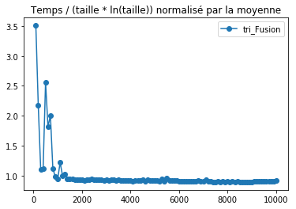

```python
def  tri_Fusion(liste): return tri_fusion(liste, 0, len(liste))
liste_tris = [tri_Fusion]
liste_taille = list(range(100, 10001, 100))
liste_rapport_taille = np.array([[0 for _ in range(len(liste_taille))] for _ in range(len(liste_tris))], dtype='float')
for i, taille in enumerate(liste_taille):
    liste = [randint(0, taille) for _ in range(taille)]
    for j, tri in enumerate(liste_tris):
        liste_rapport_taille[j][i] = timetest(tri)(liste[:]) / (liste_taille[i] * np.log(liste_taille[i]))
for k, rapport_taille  in enumerate(liste_rapport_taille):
    plt.plot(liste_taille, rapport_taille / rapport_taille.mean(), label=liste_tris[k].__name__, marker='o')
plt.title(r"Temps / (taille * ln(taille)) normalisé par la moyenne")
plt.legend()
plt.savefig('complexite-nln(n)-tri_fusion.png')
```

## Comparaison des tris

### Les tris en lice

```python
def  tri_Fusion(liste): return tri_fusion(liste, 0, len(liste))
liste_tris = [tri_selection, tri_bulles2, tri_insertion, tri_Fusion]
```

### Comparaison des tris sur des listes aléatoires

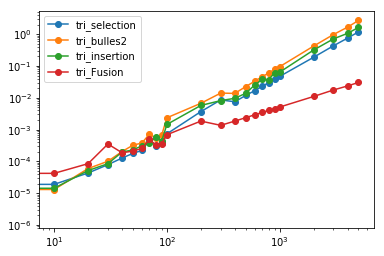

```python
liste_taille = list(range(0, 100, 10)) + list(range(100, 1000, 100)) + list(range(1000, 5001, 1000))
liste_temps = [[0 for _ in range(len(liste_taille))] for _ in range(len(liste_tris))]
for i, taille in enumerate(liste_taille):
    liste = [randint(0, taille) for _ in range(taille)]
    for j, tri in enumerate(liste_tris):
        liste_temps[j][i] = timetest(tri)(liste[:])
for k, temps in enumerate(liste_temps):
    plt.loglog(liste_taille, temps, label=liste_tris[k].__name__, marker='o')
plt.legend()
plt.savefig('test-tris-listes-aleatoires.png')
```

### Comparaison des tris sur des listes triées dans l'ordre inverse

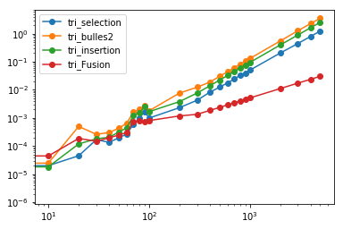

```python
liste_taille = list(range(0, 100, 10)) + list(range(100, 1000, 100)) + list(range(1000, 5001, 1000))
liste_temps = [[0 for _ in range(len(liste_taille))] for _ in range(len(liste_tris))]
for i, taille in enumerate(liste_taille):
    liste = list(range(taille))[::-1]
    for j, tri in enumerate(liste_tris):
        liste_temps[j][i] = timetest(tri)(liste[:])
for k, temps in enumerate(liste_temps):
    plt.loglog(liste_taille, temps, label=liste_tris[k].__name__, marker='o')
plt.legend()
plt.savefig('test-tris-listes-ordre-inverse.png')
```

### Comparaison des tris sur des listes déjà triées

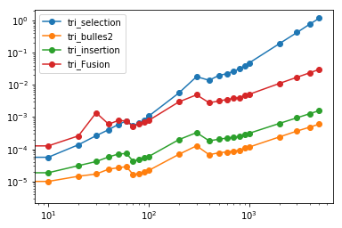

```python
liste_taille = list(range(0, 100, 10)) + list(range(100, 1000, 100)) + list(range(1000, 5001, 1000))
liste_temps = [[0 for _ in range(len(liste_taille))] for _ in range(len(liste_tris))]
for i, taille in enumerate(liste_taille):
    liste = list(range(taille))
    for j, tri in enumerate(liste_tris):
        liste_temps[j][i] = timetest(tri)(liste[:])
for k, temps in enumerate(liste_temps):
    plt.loglog(liste_taille, temps, label=liste_tris[k].__name__, marker='o')
plt.legend()
plt.savefig('test-tris-listes-deja-tri.png')
```